# Phasors

A parallel $RLC$ circuit is driven by an AC current source $I_s(t) = 100\,\sin\,(1000\,t)$. With $R = 10\,\Omega$, $L = 0.1\,$H, $C = 10\,\mu$F, determine

1. the phasor current through each component
2. the phasor voltage across the current source

(Follow the convention that $\cos\,(\omega \,t)$ corresponds to the phasor $1\,\angle {0}$.)

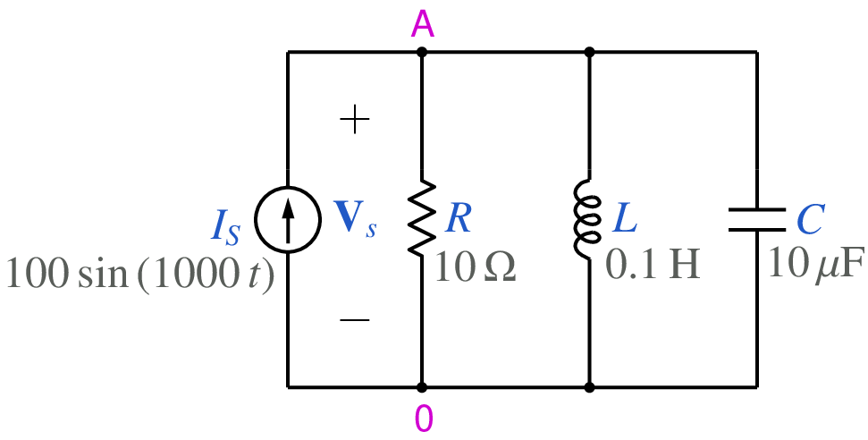

```python
from IPython.display import Image
Image(filename =r'phasor_2_fig_1.png', width=370)
```

```python
# run this cell to view the circuit file.
%pycat phasor_2_orig.in
```

We now replace strings such as \$C with the values of our choice by running the python script given below. It takes an existing circuit file `phasor_2_orig.in` and produces a new circuit file `phasor_2.in`, after replacing \$C, etc with the values of our choice.

```python
import gseim_calc as calc
s_R = '10'
s_L = '0.1'
s_C = '10e-6'
l = [
  ('$R', s_R),
  ('$L', s_L),
  ('$C', s_C),
]
calc.replace_strings_1("phasor_2_orig.in", "phasor_2.in", l)
print('phasor_2.in is ready for execution')
```

```
phasor_2.in is ready for execution
```

**Execute the following cell to run GSEIM on phasor_2.in.**

```python
import os
import dos_unix
# uncomment for windows:
#dos_unix.d2u("phasor_2.in")
os.system('run_gseim phasor_2.in')
```

```
Circuit: filename = phasor_2.in
GSEIM: Program completed.
```

```
0
```

The circuit file (`phasor_2.in`) is created in the same directory as that used for launching Jupyter notebook. The last step (i.e., running `GSEIM` on `phasor_2.in`) creates data files `phasor_2_1.dat` and `phasor_2_2.dat` in the same directory. We can now use the python code below to compute and display the quantities of interest.

```python
import numpy as np
import gseim_calc as calc
import os
import sys
import dos_unix
import matplotlib.pyplot as plt
from matplotlib.ticker import (MultipleLocator, AutoMinorLocator)
from setsize import set_size

rad_to_deg = 180.0/np.pi

slv = calc.slv("phasor_2.in")

i_slv = 0
i_out = 0
filename = slv.l_filename_all[i_slv][i_out]
print('filename:', filename)
u = np.loadtxt(filename)
IR = slv.get_scalar_complex_1(i_slv, i_out, "IR_ac", u)
IC = slv.get_scalar_complex_1(i_slv, i_out, "IC_ac", u)
IL = slv.get_scalar_complex_1(i_slv, i_out, "IL_ac", u)
IS = slv.get_scalar_complex_1(i_slv, i_out, "IS_ac", u)
VR = slv.get_scalar_complex_1(i_slv, i_out, "VR_ac", u)

s_format = "%7.2f"

print('phasors in rectangular form:')

calc.print_complex_rect('IR', IR, s_format)
calc.print_complex_rect('IL', IL, s_format)
calc.print_complex_rect('IC', IC, s_format)
calc.print_complex_rect('IS', IS, s_format)
calc.print_complex_rect('VR', IR, s_format)

print('phasors in polar form:')

calc.print_complex_polar('IR', IR, s_format)
calc.print_complex_polar('IL', IL, s_format)
calc.print_complex_polar('IC', IC, s_format)
calc.print_complex_polar('IS', IS, s_format)
calc.print_complex_polar('VR', IR, s_format)
```

```
filename: phasor_2_1.dat
phasors in rectangular form:
IR: (   0.00, -100.00)
IL: ( -10.00,   -0.00)
IC: (  10.00,    0.00)
IS: (   0.00,  100.00)
VR: (   0.00, -100.00)
phasors in polar form:
IR: magnitude:  100.00, angle:  -90.00 deg
IL: magnitude:   10.00, angle: -180.00 deg
IC: magnitude:   10.00, angle:    0.00 deg
IS: magnitude:  100.00, angle:   90.00 deg
VR: magnitude:  100.00, angle:  -90.00 deg
```

This notebook was contributed by **Prof. Nakul Narayanan K**, Govt. Engineering College, Thrissur. He may be contacted at nakul@gectcr.ac.in.